# Analysis of pH at Three Sites

## Modelling

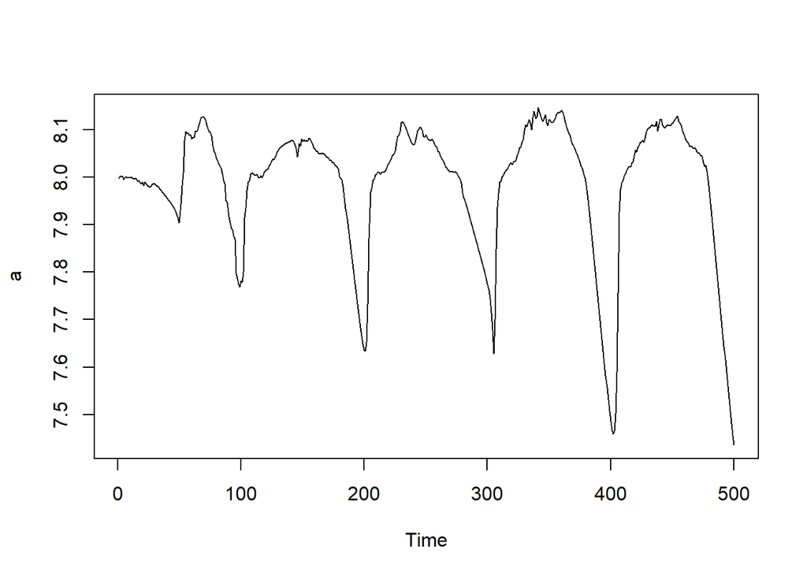

```r
a<-ph[1:500]
ts.plot(a)
```

```r
auto.arima(ts(a, frequency = 96),D=1)
```

```
## Series: ts(a, frequency = 96)
## ARIMA(0,0,1)(1,1,0)[96]
##
## Coefficients:
##          ma1    sar1
##       0.9231  0.0132
## s.e.  0.0139  0.0516
##
## sigma^2 = 0.002525:  log likelihood = 636.31
## AIC=-1266.61   AICc=-1266.55   BIC=-1254.61
```

```r
model_lol0 <- arima(a,order=c(0,0,1),seasonal = list(order=c(1,1,0),period=96))
model_lol1 <- arima(a,order=c(0,0,3),seasonal = list(order=c(0,1,3),period=96))
```

The model_lol0 is the model given by the auto.arima function. The model_lol1 is the model whose parameter is determined by the ACF and PACF charts.

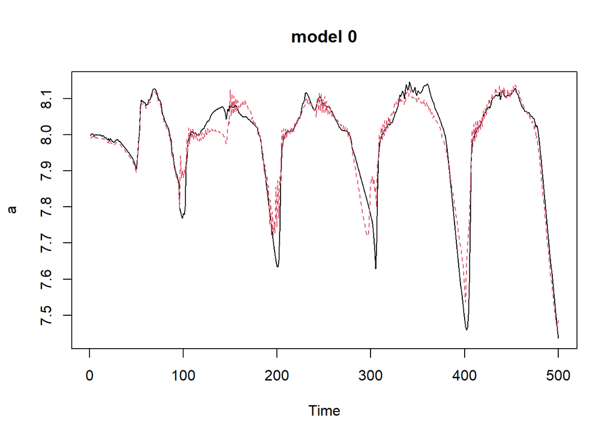

```r
residual_lol0 <- residuals(model_lol0)
msft_fitted0 <- a - residual_lol0
ts.plot(a, main = 'model 0')
points(msft_fitted0, type = "l", col = 2, lty = 2)
```

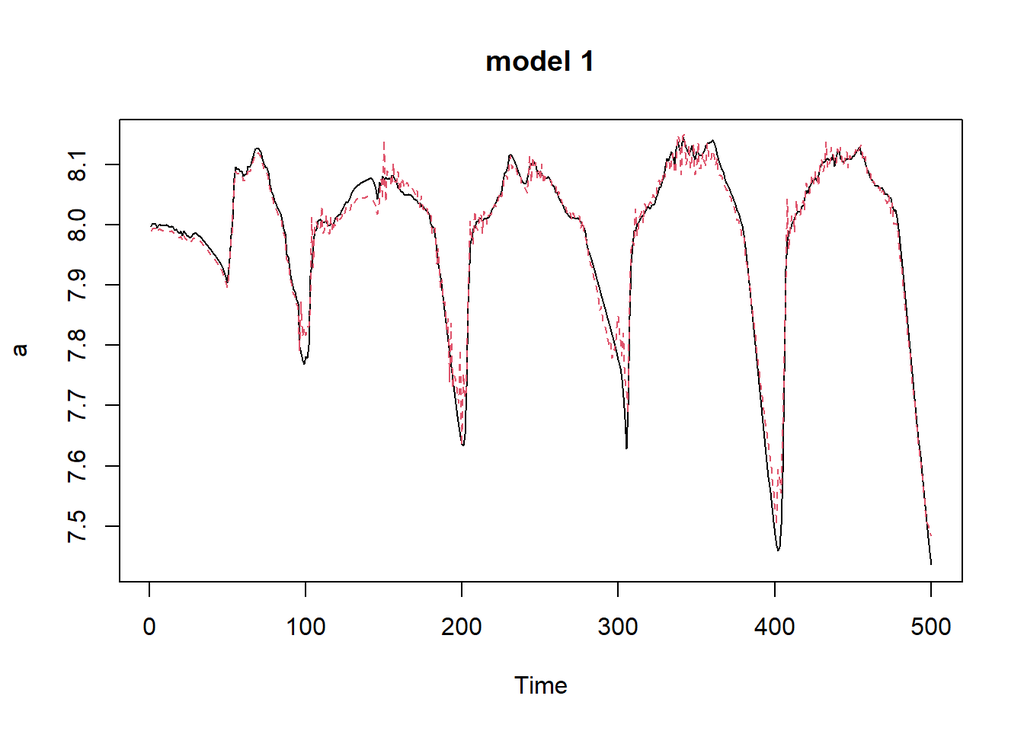

```r
residual_lol1 <- residuals(model_lol1)
msft_fitted1 <- a - residual_lol1
ts.plot(a, main = 'model 1')
points(msft_fitted1, type = "l", col = 2, lty = 2)
```

Plot the original data with the model’s prediction to show how close it fits.

## Prediction

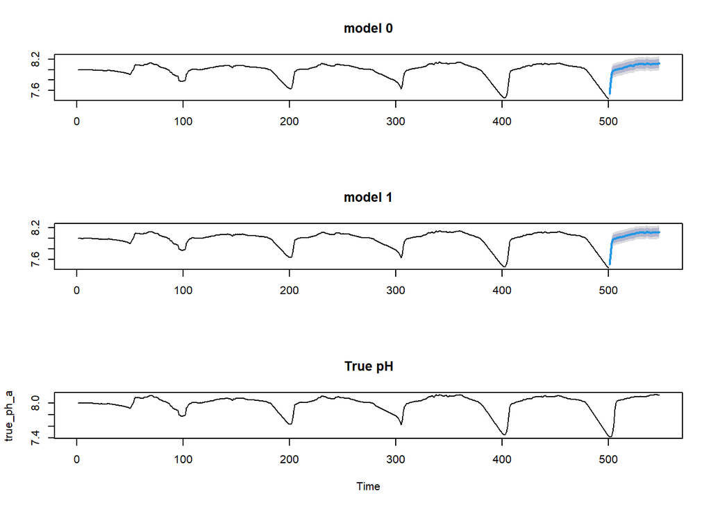

```r
x_forecast_ph0 <- forecast::forecast(model_lol0,h=4*12,level=c(0.8,0.95))
x_forecast_ph1 <- forecast::forecast(model_lol1,h=4*12,level=c(0.8,0.95))

true_ph_a=(ph[1:548])
par(mfrow=c(3,1))
plot(x_forecast_ph0,  main = 'model 0')
plot(x_forecast_ph1,  main = 'model 1')
ts.plot(true_ph_a, main = 'True pH')
```

Use forecast function to predict the next 48 data points. i.e. the pH values of the next 12 hours. The three plots are the prediction of model 0, prediction of model 1, and the true value, respectively.

We can fit the same model to the next 500 data points.

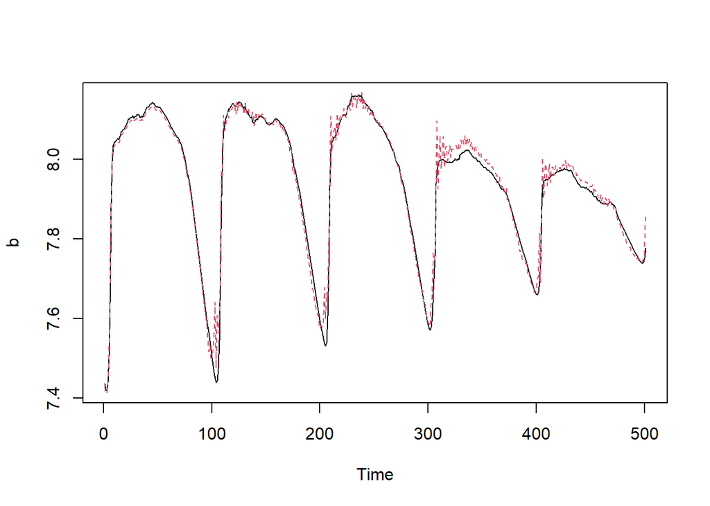

```r
b<-ph[500:1000]
ts.plot(b)
model_lol2 <- arima(b,order=c(0,0,3),seasonal = list(order=c(0,1,3),period=96))

residual_lol2 <- residuals(model_lol2)
msft_fitted2 <- b - residual_lol2
ts.plot(b)
points(msft_fitted2, type = "l", col = 2, lty = 2)
```

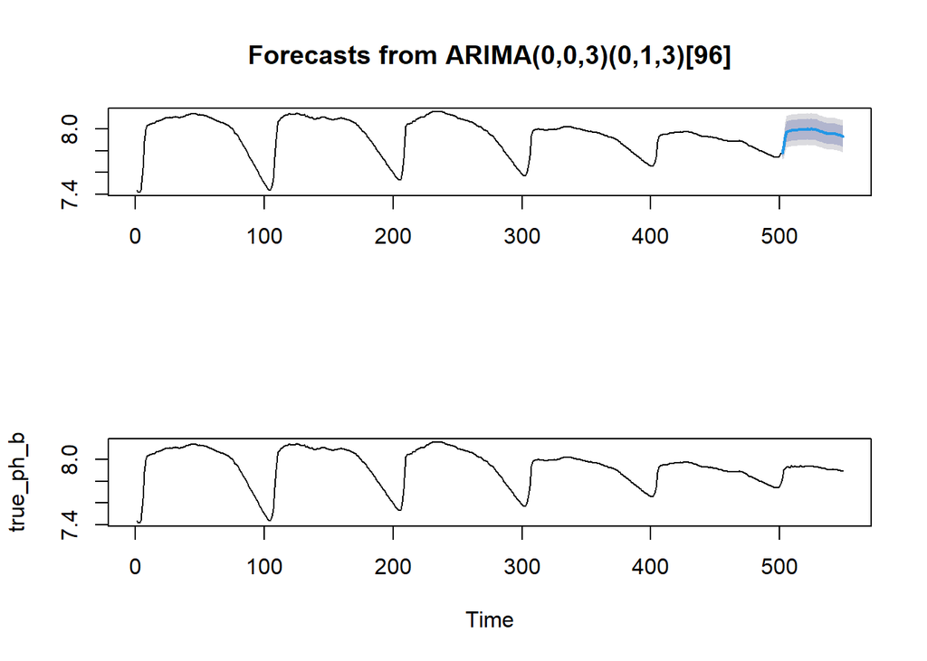

```r
x_forecast_ph2 <- forecast::forecast(model_lol2,h=4*12,level=c(0.8,0.95))

true_ph_b=(ph[500:1048])
par(mfrow=c(2,1))
plot(x_forecast_ph2)
ts.plot(true_ph_b)
```